# Motor Trend Analysis

Ricardo Arango Giraldo

20 de junio de 2018

## Executive Summary

You work for Motor Trend, a magazine about the automobile industry. Looking at a data set of a collection of cars, they are interested in exploring the relationship between a set of variables and miles per gallon (MPG) (outcome). They are particularly interested in the following two questions:

- Is an automatic or manual transmission better for MPG.
- Quantify the MPG difference between automatic and manual transmissions.

## Load Data

The data was extracted from the 1974 Motor Trend US magazine, and comprises fuel consumption and 10 aspects of automobile design and performance for 32 automobiles (1973–74 models). It consists of 32 observations on 11 variables.

```r
library(datasets)
data(mtcars)
names(mtcars)
```

```
##  [1] "mpg"  "cyl"  "disp" "hp"   "drat" "wt"   "qsec" "vs"   "am"   "gear"
## [11] "carb"
```

## Is an automatic or manual transmission better for MPG?

For automatic:

```r
summary(mtcars[mtcars$am==0,])
```

```
##       mpg             cyl             disp             hp
##  Min.   :10.40   Min.   :4.000   Min.   :120.1   Min.   : 62.0
##  1st Qu.:14.95   1st Qu.:6.000   1st Qu.:196.3   1st Qu.:116.5
##  Median :17.30   Median :8.000   Median :275.8   Median :175.0
##  Mean   :17.15   Mean   :6.947   Mean   :290.4   Mean   :160.3
##  3rd Qu.:19.20   3rd Qu.:8.000   3rd Qu.:360.0   3rd Qu.:192.5
##  Max.   :24.40   Max.   :8.000   Max.   :472.0   Max.   :245.0
##       drat             wt             qsec             vs
##  Min.   :2.760   Min.   :2.465   Min.   :15.41   Min.   :0.0000
##  1st Qu.:3.070   1st Qu.:3.438   1st Qu.:17.18   1st Qu.:0.0000
##  Median :3.150   Median :3.520   Median :17.82   Median :0.0000
##  Mean   :3.286   Mean   :3.769   Mean   :18.18   Mean   :0.3684
##  3rd Qu.:3.695   3rd Qu.:3.842   3rd Qu.:19.17   3rd Qu.:1.0000
##  Max.   :3.920   Max.   :5.424   Max.   :22.90   Max.   :1.0000
##        am         gear            carb
##  Min.   :0   Min.   :3.000   Min.   :1.000
##  1st Qu.:0   1st Qu.:3.000   1st Qu.:2.000
##  Median :0   Median :3.000   Median :3.000
##  Mean   :0   Mean   :3.211   Mean   :2.737
##  3rd Qu.:0   3rd Qu.:3.000   3rd Qu.:4.000
##  Max.   :0   Max.   :4.000   Max.   :4.000
```

For manual:

```r
summary(mtcars[mtcars$am==1,])
```

```
##       mpg             cyl             disp             hp
##  Min.   :15.00   Min.   :4.000   Min.   : 71.1   Min.   : 52.0
##  1st Qu.:21.00   1st Qu.:4.000   1st Qu.: 79.0   1st Qu.: 66.0
##  Median :22.80   Median :4.000   Median :120.3   Median :109.0
##  Mean   :24.39   Mean   :5.077   Mean   :143.5   Mean   :126.8
##  3rd Qu.:30.40   3rd Qu.:6.000   3rd Qu.:160.0   3rd Qu.:113.0
##  Max.   :33.90   Max.   :8.000   Max.   :351.0   Max.   :335.0
##       drat            wt             qsec             vs
##  Min.   :3.54   Min.   :1.513   Min.   :14.50   Min.   :0.0000
##  1st Qu.:3.85   1st Qu.:1.935   1st Qu.:16.46   1st Qu.:0.0000
##  Median :4.08   Median :2.320   Median :17.02   Median :1.0000
##  Mean   :4.05   Mean   :2.411   Mean   :17.36   Mean   :0.5385
##  3rd Qu.:4.22   3rd Qu.:2.780   3rd Qu.:18.61   3rd Qu.:1.0000
##  Max.   :4.93   Max.   :3.570   Max.   :19.90   Max.   :1.0000
##        am         gear            carb
##  Min.   :1   Min.   :4.000   Min.   :1.000
##  1st Qu.:1   1st Qu.:4.000   1st Qu.:1.000
##  Median :1   Median :4.000   Median :2.000
##  Mean   :1   Mean   :4.385   Mean   :2.923
##  3rd Qu.:1   3rd Qu.:5.000   3rd Qu.:4.000
##  Max.   :1   Max.   :5.000   Max.   :8.000
```

Hence, the mean of mpg is greater for manual (at 24.4) than automatic (at 17.1).

Investigating further..

## Quantify the MPG difference between automatic and manual transmissions.

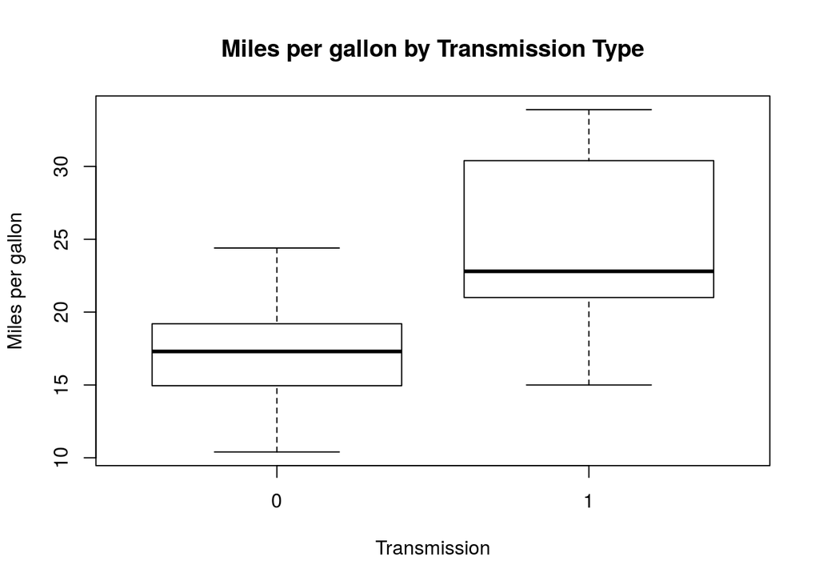

```r
boxplot(mpg ~ am, data = mtcars, xlab = "Transmission", ylab = "Miles per gallon", main="Miles per gallon by Transmission Type")
```

Manual (represented by 1) has a higher mean for mpg than automatic (represented by 0).

## Hypothesis Testing

```r
aggregate(mpg~am, data = mtcars, mean)
```

```
##   am      mpg
## 1  0 17.14737
## 2  1 24.39231
```

The mean transmission for manual is 7.24mpg higher than automatic. Let alpha=0.5.

```r
auto <- mtcars[mtcars$am == 0,]
manual <- mtcars[mtcars$am == 1,]
t.test(auto$mpg, manual$mpg)
```

```
##
##  Welch Two Sample t-test
##
## data:  auto$mpg and manual$mpg
## t = -3.7671, df = 18.332, p-value = 0.001374
## alternative hypothesis: true difference in means is not equal to 0
## 95 percent confidence interval:
##  -11.280194  -3.209684
## sample estimates:
## mean of x mean of y
##  17.14737  24.39231
```

Since p-value = 0.001374, we reject the null hypothesis. There is a major difference between mpg of manual and automatic transmissions.

```r
m<-lm(mpg~am,data=mtcars)
summary(m)
```

```
##
## Call:
## lm(formula = mpg ~ am, data = mtcars)
##
## Residuals:
##     Min      1Q  Median      3Q     Max
## -9.3923 -3.0923 -0.2974  3.2439  9.5077
##
## Coefficients:
##             Estimate Std. Error t value Pr(>|t|)
## (Intercept)   17.147      1.125  15.247 1.13e-15 ***
## am             7.245      1.764   4.106 0.000285 ***
## ---
## Signif. codes:  0 '***' 0.001 '**' 0.01 '*' 0.05 '.' 0.1 ' ' 1
##
## Residual standard error: 4.902 on 30 degrees of freedom
## Multiple R-squared:  0.3598, Adjusted R-squared:  0.3385
## F-statistic: 16.86 on 1 and 30 DF,  p-value: 0.000285
```

From the above, we may conclude that automatic run at 17.15mpg, while manual have 7.24 more mpg.

Also, R^2 is 0.36, hence the model only accounts for 36% variance.

Performing multivariate linear regression:

```r
model <- lm(mpg~am + wt + hp + cyl, data = mtcars)
anova(m,model)
```

```
## Analysis of Variance Table
##
## Model 1: mpg ~ am
## Model 2: mpg ~ am + wt + hp + cyl
##   Res.Df   RSS Df Sum of Sq      F    Pr(>F)
## 1     30 720.9
## 2     27 170.0  3     550.9 29.166 1.274e-08 ***
## ---
## Signif. codes:  0 '***' 0.001 '**' 0.01 '*' 0.05 '.' 0.1 ' ' 1
```

The final model is below:

```r
summary(model)
```

```
##
## Call:
## lm(formula = mpg ~ am + wt + hp + cyl, data = mtcars)
##
## Residuals:
##     Min      1Q  Median      3Q     Max
## -3.4765 -1.8471 -0.5544  1.2758  5.6608
##
## Coefficients:
##             Estimate Std. Error t value Pr(>|t|)
## (Intercept) 36.14654    3.10478  11.642 4.94e-12 ***
## am           1.47805    1.44115   1.026   0.3142
## wt          -2.60648    0.91984  -2.834   0.0086 **
## hp          -0.02495    0.01365  -1.828   0.0786 .
## cyl         -0.74516    0.58279  -1.279   0.2119
## ---
## Signif. codes:  0 '***' 0.001 '**' 0.01 '*' 0.05 '.' 0.1 ' ' 1
##
## Residual standard error: 2.509 on 27 degrees of freedom
## Multiple R-squared:  0.849,  Adjusted R-squared:  0.8267
## F-statistic: 37.96 on 4 and 27 DF,  p-value: 1.025e-10
```

## APPENDIX

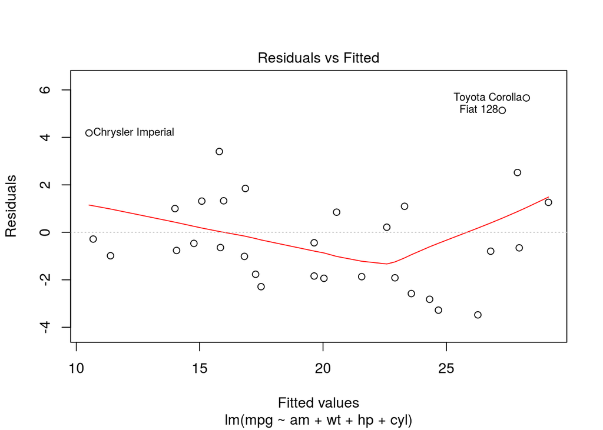

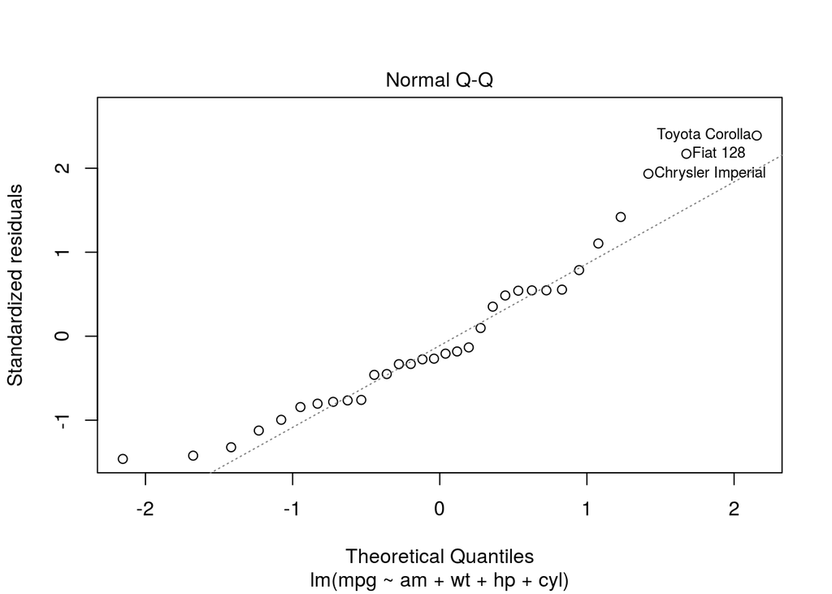

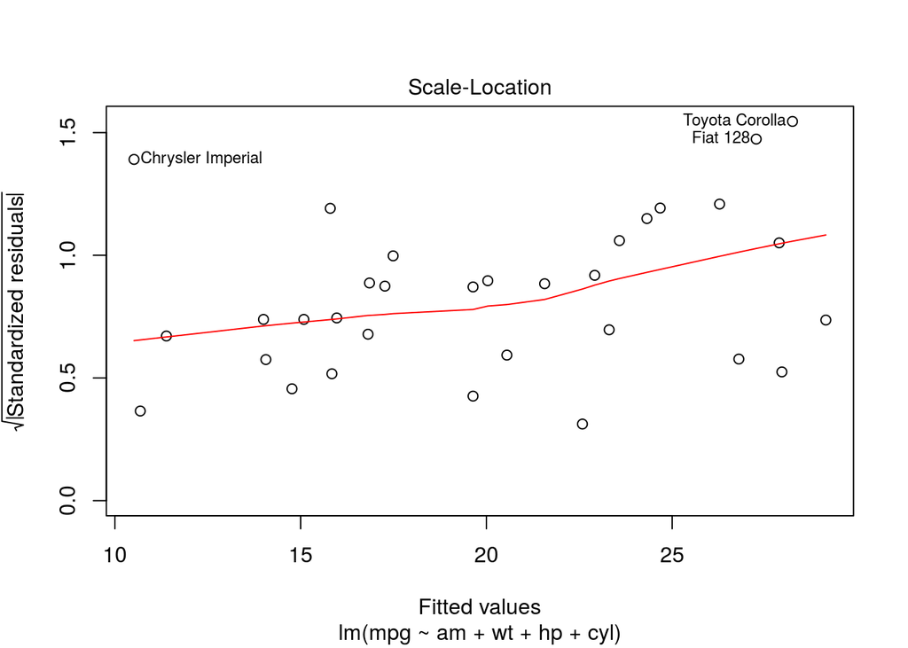

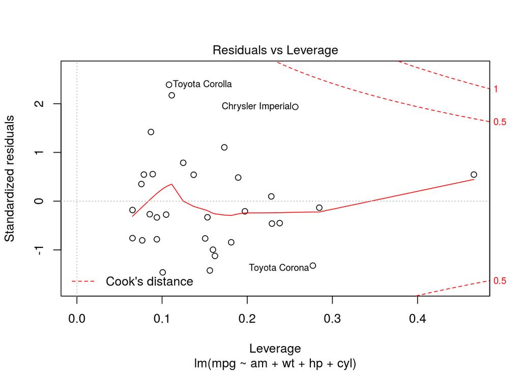

```r
plot(model)
```